# DATA 624: PREDICTIVE ANALYTICS Project 1

# Part B

## EDA & Cleanup

```r
str(power_raw)
```

```
tibble [192 × 3] (S3: tbl_df/tbl/data.frame)
 $ CaseSequence: num [1:192] 733 734 735 736 737 738 739 740 741 742 ...
 $ YYYY-MMM    : chr [1:192] "1998-Jan" "1998-Feb" "1998-Mar" "1998-Apr" ...
 $ KWH         : num [1:192] 6862583 5838198 5420658 5010364 4665377 ...
```

```r
describe(power_raw)
```

|  | vars | n | mean | sd | median | trimmed | mad | min | max | range | skew | kurtosis | se |
| --- | --- | --- | --- | --- | --- | --- | --- | --- | --- | --- | --- | --- | --- |
| CaseSequence | 1 | 192 | 828.5 | 55.57 | 828.5 | 828.5 | 71.16 | 733 | 924 | 191 | 0.00 | -1.22 | 4.01 |
| YYYY-MMM* | 2 | 192 | 96.5 | 55.57 | 96.5 | 96.5 | 71.16 | 1 | 192 | 191 | 0.00 | -1.22 | 4.01 |
| KWH | 3 | 191 | 6502474.6 | 1447570.89 | 6283324.0 | 6439474.9 | 1543073.77 | 770523 | 10655730 | 9885207 | 0.17 | 0.45 | 104742.55 |

```r
data.frame(power_raw$`YYYY-MMM`[power_raw$KWH %in% NA])
```

| power_raw..YYYY.MMM..power_raw.KWH..in..NA. |
| --- |
| 2008-Sep |

I renamed the `YYYY-MMM` for preference to `DATE`. The cleanup is a change of type for `DATE`, removal of `CaseSequence` as it does not help our model, and reducing our model to values in the thousands for ease of analysis. Like before we’ll also be indexing by DATE

```r
#change variable type
power_df <- power_raw %>%
  mutate(DATE = yearmonth(`YYYY-MMM`), KWH = KWH/1000) %>%
  select(-CaseSequence, -'YYYY-MMM') %>%
  tsibble(index= DATE)
```

```r
head(power_df)
```

| KWH | DATE |
| --- | --- |
| 6862.583 | 1998 Jan |
| 5838.198 | 1998 Feb |
| 5420.658 | 1998 Mar |
| 5010.364 | 1998 Apr |
| 4665.377 | 1998 May |
| 6467.147 | 1998 Jun |

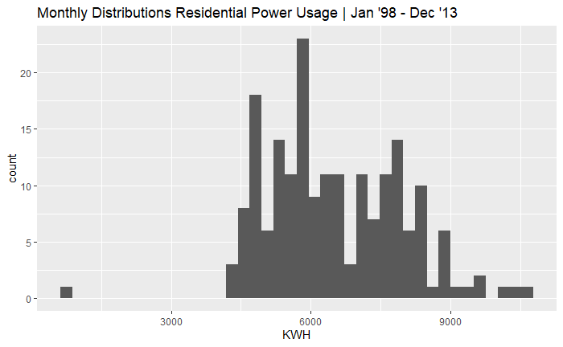

```r
ggplot(power_df, aes(x=KWH))+
  geom_histogram(bins=40)+
  labs(title = "Monthly Distributions Residential Power Usage | Jan '98 - Dec '13")
```

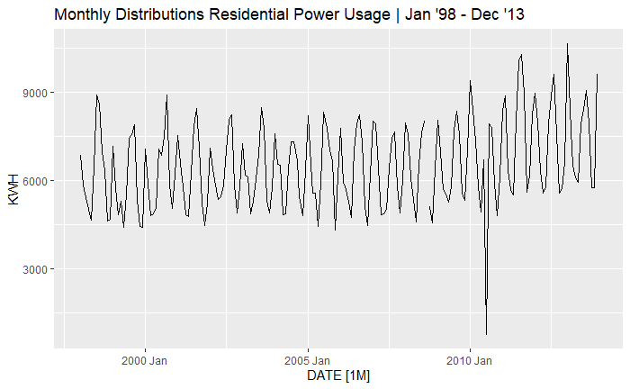

```r
power_df %>%
  autoplot(KWH) +
  labs(title = "Monthly Distributions Residential Power Usage | Jan '98 - Dec '13")
```

The data has an apparent outlier and is right skewed that appears in both plots, and resides sometime after January of 2010.

```r
# made a copy of the data first
power_df2<-power_df
power_df2$KWH <- na.interp(power_df2$KWH)
power_df2$KWH <- replace(power_df2$KWH, power_df2$KWH == min(power_df2$KWH),
                          median(power_df2$KWH))
```

Considering the distribution, I again thought it best to replace the missing value with the median, but considering I will be using that method to address the outlier, I decided to use `na.interp` since its a tool used by the author of our textbook Rob J Hydman’s [github repo](https://github.com/robjhyndman/forecast/blob/master/man/na.interp.Rd). Regardless, the transformation below shows its still right skewed but shows seasonality with an upward trend.

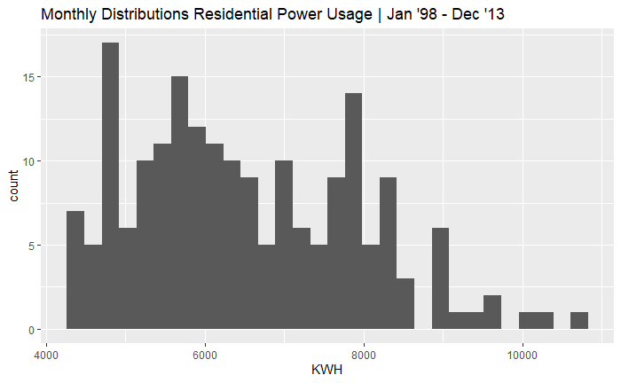

```r
ggplot(power_df2, aes(x=KWH))+
  geom_histogram()+
  labs(title = "Monthly Distributions Residential Power Usage | Jan '98 - Dec '13")
```

```r
#summary
summary(power_df2$KWH)
```

```
   Min. 1st Qu.  Median    Mean 3rd Qu.    Max.
   4313    5444    6330    6532    7609   10656
```

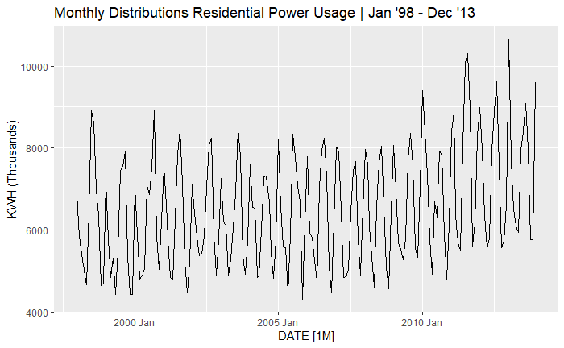

```r
#ts plot
power_df2 %>%
  autoplot(KWH) +
  labs(title = "Monthly Distributions Residential Power Usage | Jan '98 - Dec '13")+
  ylab(label= "KWH (Thousands)")
```

Before forecasting I will transform the data using a Box-Cox transformation.

```r
#get lambda
(power_lambda <- power_df2 %>%
  features(KWH, features = guerrero) %>%
  pull(lambda_guerrero))
```

```
[1] -0.2130548
```

```r
power_df2 <- power_df2 %>%
    mutate(KWH_bc = box_cox(KWH, power_lambda))


summary(power_df2$KWH_bc)
```

```
   Min. 1st Qu.  Median    Mean 3rd Qu.    Max.
  3.905   3.943   3.967   3.967   3.994   4.043
```

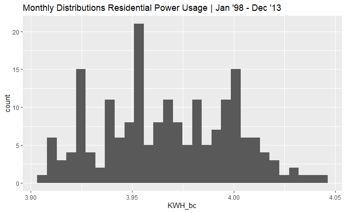

```r
ggplot(power_df2, aes(x=KWH_bc))+
  geom_histogram()+
  labs(title = "Monthly Distributions Residential Power Usage | Jan '98 - Dec '13")
```

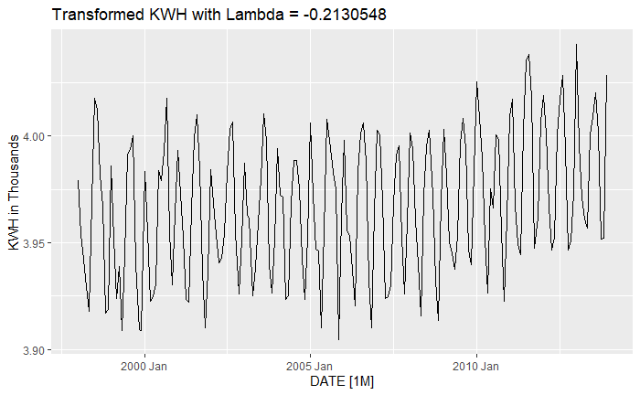

```r
power_df2 %>%
  autoplot(KWH_bc) +
  labs(y = "KWH in Thousands",
       title = "Transformed KWH with Lambda = -0.2130548")
```

## STL Decomposition

- STL decomposition again used to identify seasonality, variance, etc.
- ndiff() and ACF will identify if differencing is needed.

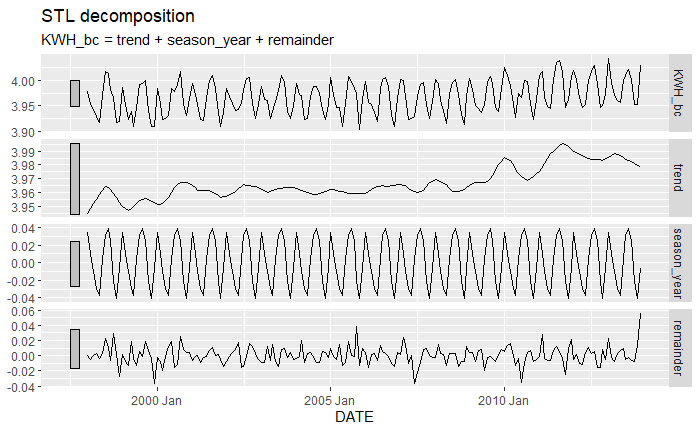

```r
power_df2 %>%
  model(
    STL(KWH_bc ~ trend(window = 13) +
                   season(window = "periodic"),
                      robust = TRUE)) %>%
                        components() %>%
                            autoplot()
```

```r
ndiffs(power_df2$KWH_bc)
```

```
[1] 1
```

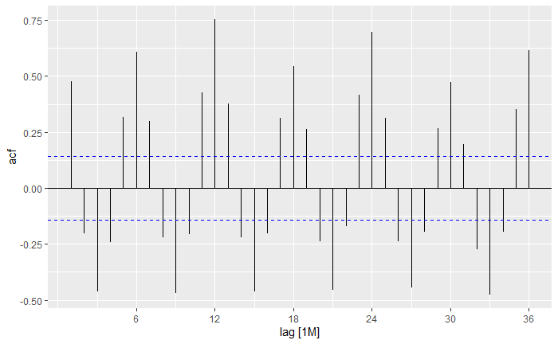

```r
power_df2 %>%
  ACF(KWH_bc, lag_max = 36) %>%
  autoplot()
```

Differencing is needed.

```r
diff_power <- power_df2 %>%
  mutate(diff_KWH= difference(KWH), diff_KWH_bc = difference(KWH_bc))
```

- Differencing created
- NA and some columns need removal

```r
diff_power<-diff_power%>%
  select(-KWH, -KWH_bc)%>%
                        slice(-1)

ndiffs(diff_power$diff_KWH_bc)
```

```
[1] 0
```